# Exam 3

Jake Hiltscher

# Exam Instructions

Use this .rmd file to perform your analysis. You will answer questions about this data set through a Canvas Quiz. You will then submit your completed .rmd and .html file at the end of the Canvas quiz. Your code should be organized, properly formatted, and you should only print out relevant items (e.g. do not print out the entire data set for me to see, and do not use the `View()` function).

**Note that there are two parts (separate analyses) for this Exam**

# Data and Description

A company that sells outdoor equipment collected data on 371 customers. The company sells a variety of products and is considering selling snowshoes. The following variables were recorded:

| Variable | Description |
| --- | --- |
| age | Age of the customer in years |
| product | The primary type of product the customer has previously purchased. One of: “winterSports” (used as the baseline), “mountainSports”, “waterSports” |
| quantity | The total number of unique products the customer has previously purchased |
| tenure | The number of days since the customers’ first purchase |
| snowshoes | Indication of purchasing snowshoes in the future, if the company were to sell them. One of: 1 (the customer indicated they would buy snowshoes), 0 (the customer indicated they would not buy snowshoes) |

Download the snowshoe.txt file from Canvas (Files -> DATA SETS), and put it in the same folder as this R Markdown file.

## PART 1 (PREDICT SNOWSHOES) ———————————————–

For Part 1 of this analysis, you will address the company’s first goal of using the data from their current customers to create a model to predict whether a particular customer will buy snowshoes.

### Complete your exploratory data analysis (EDA) in this section. You may use multiple code chunks, if you wish, to organize your code.

```r
#READ IN DATA
snowshoe <- read.table("snowshoe.txt", header = TRUE) %>%
  mutate_if(is.character, as.factor) %>% mutate(snowshoes = as.factor(snowshoes))

#SET BASELINE winterSports
snowshoe <- within(snowshoe, product <- relevel(product, ref = 3))

summary(snowshoe)
```

```
##     quantity          tenure           age                  product
##  Min.   : 2.000   Min.   :12.00   Min.   :19.00   winterSports  :217
##  1st Qu.: 6.000   1st Qu.:25.00   1st Qu.:34.50   mountainSports:105
##  Median : 8.000   Median :32.00   Median :49.00   waterSports   : 49
##  Mean   : 9.402   Mean   :32.22   Mean   :46.58
##  3rd Qu.:12.000   3rd Qu.:38.00   3rd Qu.:59.00
##  Max.   :30.000   Max.   :72.00   Max.   :68.00
##  snowshoes
##  0:204
##  1:167
##
##
##
##
```

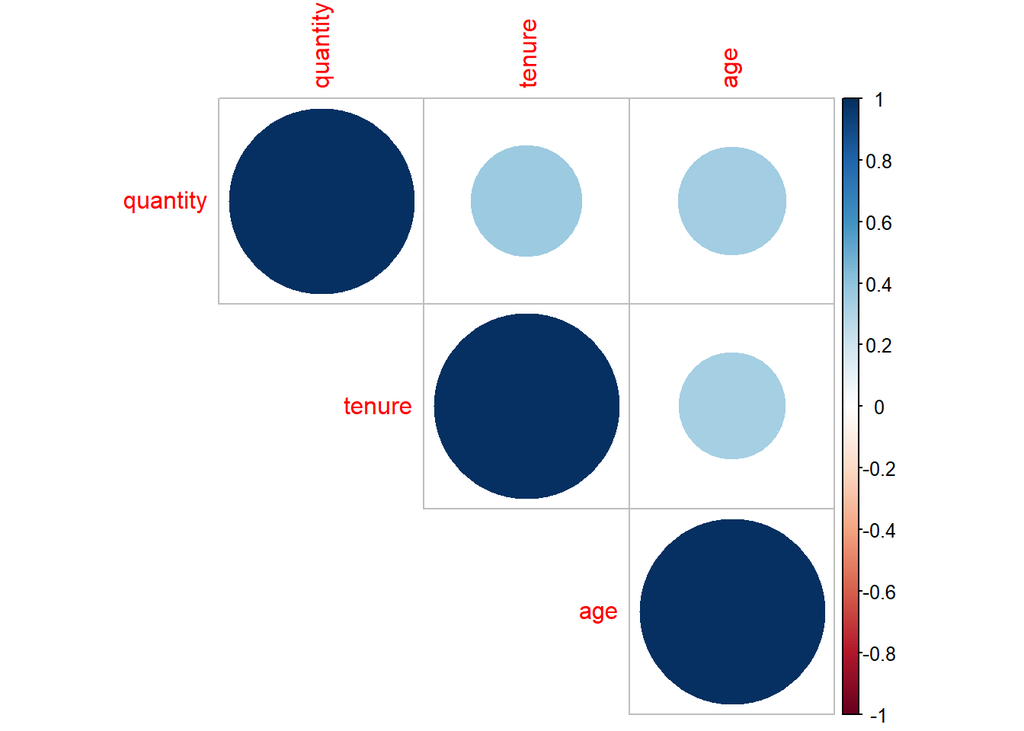

```r
corrplot(cor(snowshoe %>% select(-c("snowshoes", "product"))), type = "upper")
```

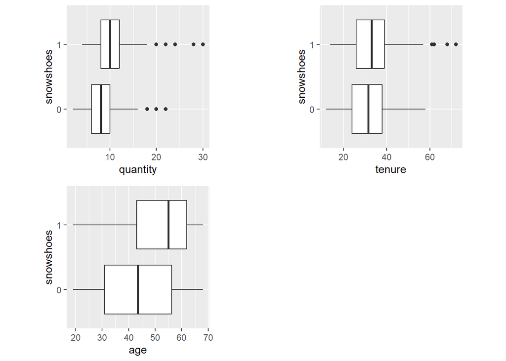

```r
# Boxplot for quantity
box_quantity <- ggplot(data = snowshoe) +
  geom_boxplot(mapping = aes(y = quantity, x = snowshoes)) +
  theme(aspect.ratio = 1) +
  coord_flip()

# Boxplot for tenure
box_tenure <- ggplot(data = snowshoe) +
  geom_boxplot(mapping = aes(y = tenure, x = snowshoes)) +
  theme(aspect.ratio = 1) +
  coord_flip()

# Boxplot for age
box_age <- ggplot(data = snowshoe) +
  geom_boxplot(mapping = aes(y = age, x = snowshoes)) +
  theme(aspect.ratio = 1) +
  coord_flip()

grid.arrange(box_quantity,
             box_tenure,
             box_age,
             nrow = 2)
```

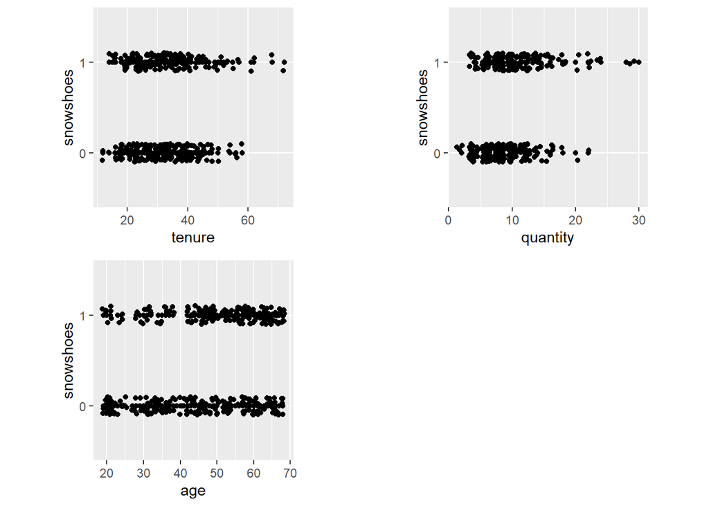

```r
# Jittered Scatterplot for tenure
jit_tenure <- ggplot(data = snowshoe) +
  geom_point(mapping = aes(y = snowshoes, x = tenure)) +
  geom_jitter(mapping = aes(y = snowshoes, x = tenure),
              height = 0.1) +
  theme(aspect.ratio = 1)

# Jittered Scatterplot for quantity
jit_quantity <- ggplot(data = snowshoe) +
  geom_point(mapping = aes(y = snowshoes, x = quantity)) +
  geom_jitter(mapping = aes(y = snowshoes, x = quantity),
              height = 0.1) +
  theme(aspect.ratio = 1)

# Jittered Scatterplot for age
jit_age <- ggplot(data = snowshoe) +
  geom_point(mapping = aes(y = snowshoes, x = age)) +
  geom_jitter(mapping = aes(y = snowshoes, x = age),
              height = 0.1) +
  theme(aspect.ratio = 1)

grid.arrange(jit_tenure,
             jit_quantity,
             jit_age,
             nrow = 2)
```

### Perform variable selection in this section. You may use multiple code chunks, if you wish, to organize your code.

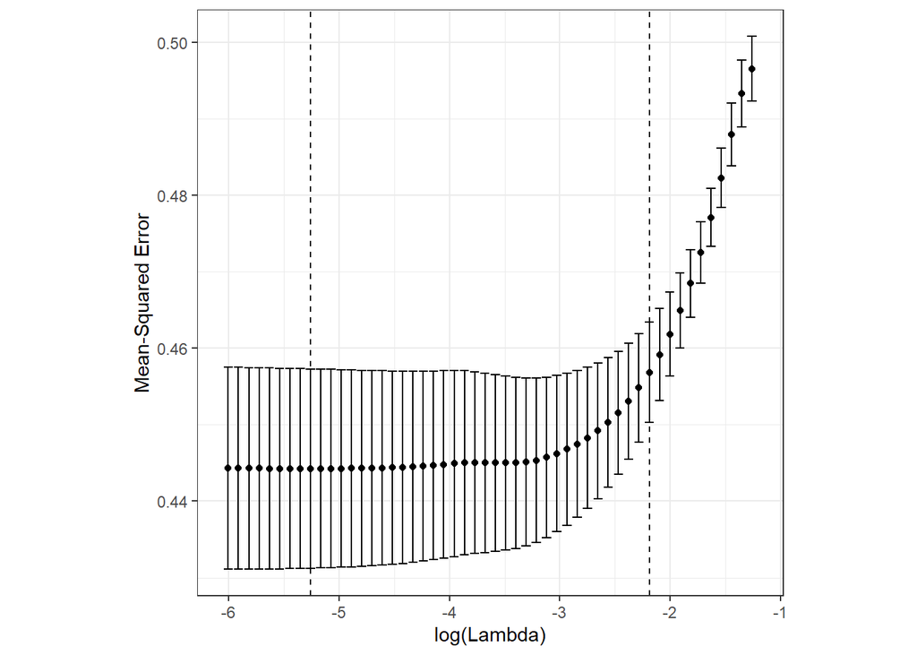

```r
snowshoe_x <- as.matrix(snowshoe[, 1:3])
snowshoe_y <- snowshoe[, 5]

# use cross validation to pick the "best" (based on MSE) lambda
snowshoe_ridge_cv <- cv.glmnet(x = snowshoe_x,
                          y = snowshoe_y,
                          type.measure = "mse",
                          alpha = 0.5, family = "binomial")  # 0.5 is code for "Elastic Net"

# plot (log) lambda vs MSE
autoplot(snowshoe_ridge_cv, label = FALSE) +
  theme_bw() +
  theme(aspect.ratio = 1)
```

```r
# lambda.min: value of lambda that gives minimum mean cross-validated error
snowshoe_ridge_cv$lambda.min
```

```
## [1] 0.005196521
```

```r
# lambda.1se: value of lambda within 1 standard error of the minimum
# cross-validated error
snowshoe_ridge_cv$lambda.1se
```

```
## [1] 0.1119557
```

```r
coef(snowshoe_ridge_cv, s = "lambda.min")
```

```
## 4 x 1 sparse Matrix of class "dgCMatrix"
##                      s1
## (Intercept) -2.44306690
## quantity     0.10863873
## tenure      -0.01088799
## age          0.03327402
```

```r
coef(snowshoe_ridge_cv, s = "lambda.1se")
```

```
## 4 x 1 sparse Matrix of class "dgCMatrix"
##                      s1
## (Intercept) -1.38312978
## quantity     0.04634024
## tenure       .
## age          0.01591136
```

```r
# BEST SUBSETS using BIC
snowshoe_best_subsets_bic <- bestglm(as.data.frame(snowshoe),
                                  IC = "BIC",
                                  method = "exhaustive",
                                  TopModels = 1,
                                  family = binomial)
```

```
## Morgan-Tatar search since family is non-gaussian.
```

```
## Note: factors present with more than 2 levels.
```

```r
summary(snowshoe_best_subsets_bic$BestModel)
```

```
##
## Call:
## glm(formula = y ~ ., family = family, data = Xi, weights = weights)
##
## Deviance Residuals:
##     Min       1Q   Median       3Q      Max
## -2.1021  -0.9530  -0.4264   0.9828   2.1632
##
## Coefficients:
##                        Estimate Std. Error z value Pr(>|z|)
## (Intercept)           -2.537831   0.460536  -5.511 3.58e-08 ***
## quantity               0.115997   0.032145   3.609 0.000308 ***
## age                    0.037884   0.008733   4.338 1.44e-05 ***
## productmountainSports -1.073872   0.268948  -3.993 6.53e-05 ***
## productwaterSports    -2.177337   0.434736  -5.008 5.49e-07 ***
## ---
## Signif. codes:  0 '***' 0.001 '**' 0.01 '*' 0.05 '.' 0.1 ' ' 1
##
## (Dispersion parameter for binomial family taken to be 1)
##
##     Null deviance: 510.62  on 370  degrees of freedom
## Residual deviance: 425.48  on 366  degrees of freedom
## AIC: 435.48
##
## Number of Fisher Scoring iterations: 4
```

### Fit a model using the variables you selected from the prevous section, and determine in any interaction(s) are needed for this model in this section. You may use multiple code chunks, if you wish, to organize your code.

```r
# Logistic regression Model

snowshoe_logistic <- snowshoe_best_subsets_bic$BestModel
anova(snowshoe_logistic)
```

```
## Analysis of Deviance Table
##
## Model: binomial, link: logit
##
## Response: y
##
## Terms added sequentially (first to last)
##
##
##          Df Deviance Resid. Df Resid. Dev
## NULL                       370     510.62
## quantity  1   27.993       369     482.63
## age       1   16.710       368     465.92
## product   2   40.437       366     425.48
```

```r
#INTERACTION ANOVA
new.model <- update(snowshoe_logistic,snowshoes ~ (.)^2, data = snowshoe, family = "binomial")
anova(new.model, snowshoe_logistic,test = "LRT")
```

```
## Analysis of Deviance Table
##
## Model: binomial, link: logit
##
## Response: snowshoes
##
## Terms added sequentially (first to last)
##
##
##                  Df Deviance Resid. Df Resid. Dev  Pr(>Chi)
## NULL                               370     510.62
## quantity          1   27.993       369     482.63 1.217e-07 ***
## age               1   16.710       368     465.92 4.355e-05 ***
## product           2   40.437       366     425.48 1.656e-09 ***
## quantity:age      1    1.106       365     424.37    0.2930
## quantity:product  2    0.928       363     423.44    0.6289
## age:product       2    4.504       361     418.94    0.1052
## ---
## Signif. codes:  0 '***' 0.001 '**' 0.01 '*' 0.05 '.' 0.1 ' ' 1
```

### Based on your results above, fit an appropriate (“final”) model and check model assumptions in this section. You may use multiple code chunks, if you wish, to organize your code.

```r
# FINAL MODEL
summary(snowshoe_logistic)
```

```
##
## Call:
## glm(formula = y ~ ., family = family, data = Xi, weights = weights)
##
## Deviance Residuals:
##     Min       1Q   Median       3Q      Max
## -2.1021  -0.9530  -0.4264   0.9828   2.1632
##
## Coefficients:
##                        Estimate Std. Error z value Pr(>|z|)
## (Intercept)           -2.537831   0.460536  -5.511 3.58e-08 ***
## quantity               0.115997   0.032145   3.609 0.000308 ***
## age                    0.037884   0.008733   4.338 1.44e-05 ***
## productmountainSports -1.073872   0.268948  -3.993 6.53e-05 ***
## productwaterSports    -2.177337   0.434736  -5.008 5.49e-07 ***
## ---
## Signif. codes:  0 '***' 0.001 '**' 0.01 '*' 0.05 '.' 0.1 ' ' 1
##
## (Dispersion parameter for binomial family taken to be 1)
##
##     Null deviance: 510.62  on 370  degrees of freedom
## Residual deviance: 425.48  on 366  degrees of freedom
## AIC: 435.48
##
## Number of Fisher Scoring iterations: 4
```

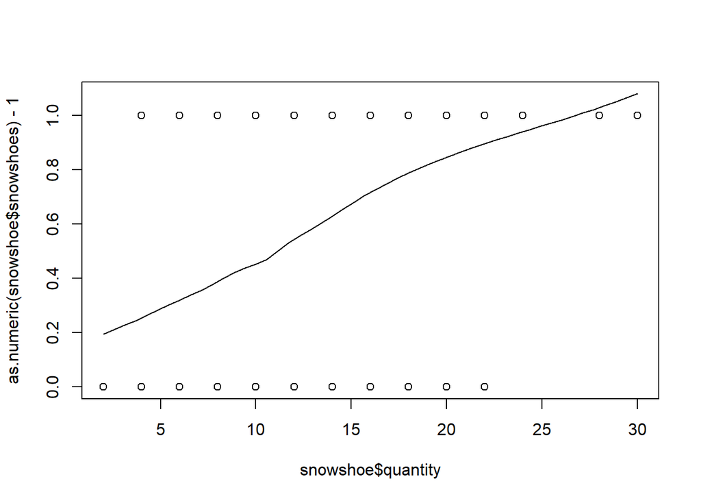

```r
#LINEARITY
#quantity
scatter.smooth(x = snowshoe$quantity, y = as.numeric(snowshoe$snowshoes) - 1)
```

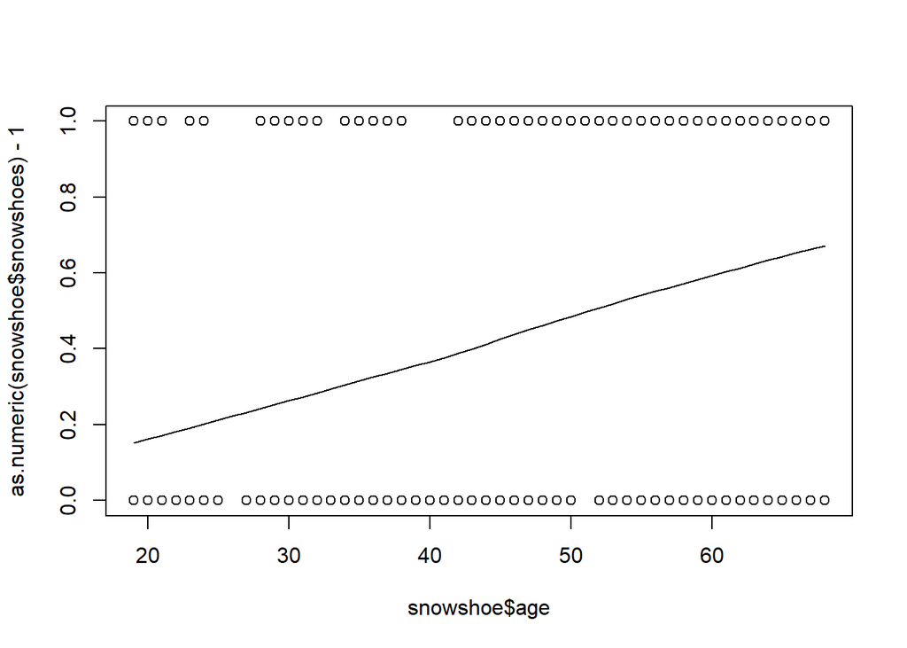

```r
# age
scatter.smooth(x = snowshoe$age, y = as.numeric(snowshoe$snowshoes) - 1)
```

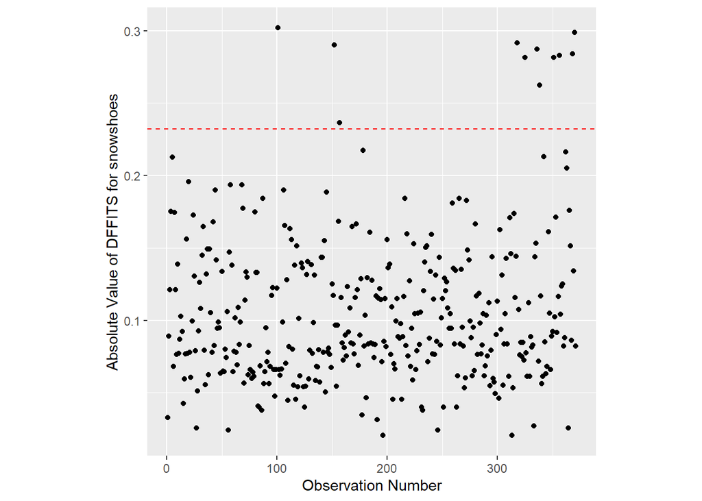

```r
#DFFITS
snowshoe$dffits <- dffits(snowshoe_logistic)

 ggplot(data = snowshoe) +
   geom_point(mapping = aes(x = as.numeric(rownames(snowshoe)),
                            y = abs(dffits))) +
   ylab("Absolute Value of DFFITS for snowshoes") +
   xlab("Observation Number") +
   # for n > 30
   geom_hline(mapping = aes(yintercept = 2 * sqrt(length(snowshoe_logistic$coefficients) /
                                                    length(dffits))),
              color = "red",
              linetype = "dashed") +
   theme(aspect.ratio = 1)
```

```r
#MULTICOLLINEARITY
vif(snowshoe_logistic)
```

```
##              GVIF Df GVIF^(1/(2*Df))
## quantity 1.084980  1        1.041624
## age      1.091764  1        1.044875
## product  1.053354  2        1.013080
```